# Autocorrelation and Normality Tests

Empirical Distribution of S&P500 Returns

Shirley He

# 1 Notebook Contents

- Clean up, Load Libraries
- ADF on &$P500 Price
- ADF on S&P500 Returns
- Histogram, QQ Plot, Kernel Histogram
- Descriptive Statistics and JB Test
- ACF, PACF, and Ljung-Box Test
- Finish Up with Virtual Environment

# 2 Clean up and load libraries

```r
rm( list=ls() )
library(tseries)
library(moments)
```

# 3 ADF Test on Price Series

The p-value from the Augmented Dickey-Fuller test is 0.9249  
The null of ADF test is that the data are non-stationary.  
We want to reject the null hypothesis for this test, so we want a p-value of 0.05 or smaller.

We hope that if we take log differences of this, the p-value will go down

```r
D <- read.table('../data/sp500.csv',header=TRUE,sep=',')
colnames(D)
```

```
## [1] "timestamp"         "open"              "high"
## [4] "low"               "close"             "adjusted_close"
## [7] "volume"            "dividend_amount"   "split_coefficient"
```

```r
#reverse adjusted close column. take it as sp500
sp500 <- rev(D$adjusted_close)

adf.test(sp500) #p-value = 0.9249
```

```
##
##  Augmented Dickey-Fuller Test
##
## data:  sp500
## Dickey-Fuller = -1.0862, Lag order = 17, p-value = 0.9249
## alternative hypothesis: stationary
```

# 4 ADF Test on Returns Series

The p-value from the Augmented Dickey-Fuller test is 0.01

```r
D_returns <- read.table('../data/sp500-returns.csv');

#2 columns: dates and returns
dates <- as.Date(as.character(D_returns[,1]),'%Y-%m-%d')
ret   <- D_returns[,2]

adf.test(ret)
```

```
##
##  Augmented Dickey-Fuller Test
##
## data:  ret
## Dickey-Fuller = -17.316, Lag order = 17, p-value = 0.01
## alternative hypothesis: stationary
```

# 5 Histogram, QQ Plot and Kernel Histogram of Returns

### 5.0.1 Histogram

When we have time series data, the first thing to do is plot a histogram.  
We see that the data is clearly not gaussian.

Gaussian has some observations at 5, -5, 10, -10 so the tails are not exponentially decaying like in normal.  
If this were gaussian, the likelihood of seeing 5 should be almost never.  
Even if we play with the mean and variance (increase variance to flatten it), we could still not fit a gaussian in here.

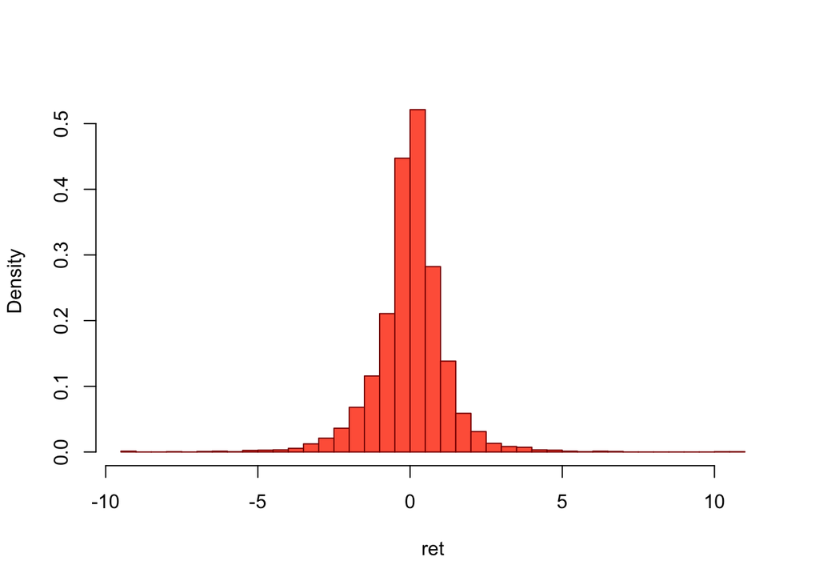

```r
hist(ret,50,freq=FALSE,col='tomato',border='darkred',main='') #main=title
```

## 5.1 QQ Plot

Ifthe data is Gaussian, we know exactly the numbers of the quantiles  
Here we compute the sample quantiles from our data and compare it to gaussian quantiles

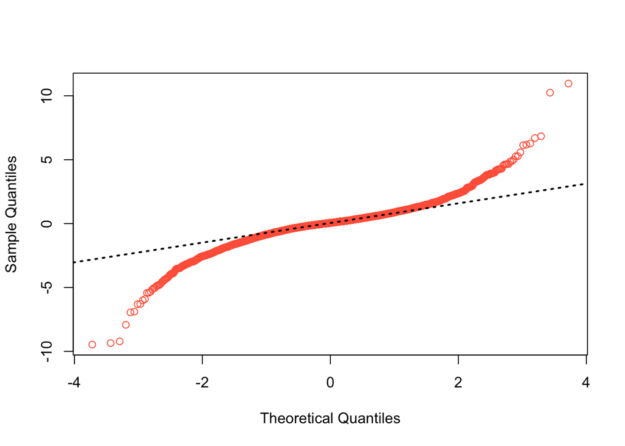

```r
qqnorm(ret,col='tomato',main='')
qqline(ret,lwd=2,lty=3)
```

## 5.2 Kernel Histogram

We need an empirical estimate of the distribution.

Notes: - ‘density’ is the kernel function in R  
- ‘polygon’ function needs a start and end to fill, but passing kernel to it will fill what’s in between the area under the shape

```r
kernel <- density(ret)
kernel
```

```
##
## Call:
##  density.default(x = ret)
##
## Data: ret (5030 obs.);   Bandwidth 'bw' = 0.1267
##
##        x                 y
##  Min.   :-9.8496   Min.   :0.0000000
##  1st Qu.:-4.5529   1st Qu.:0.0001881
##  Median : 0.7438   Median :0.0014968
##  Mean   : 0.7438   Mean   :0.0471533
##  3rd Qu.: 6.0405   3rd Qu.:0.0176446
##  Max.   :11.3372   Max.   :0.5853109
```

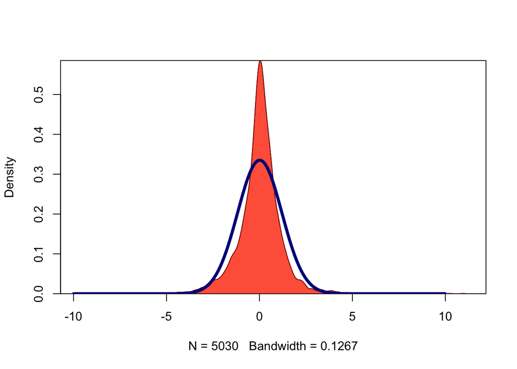

```r
#kernel object has a plot method. so when you call plot on it, it will plot something already for you.
plot(kernel , main='' , yaxs='i' )
polygon(kernel , col="tomato" , border='darkred' ) #we fill it using polygon.

lines( seq(-10,10,0.1) , dnorm( seq(-10,10,0.1) , mean(ret) , sd(ret) ) , col='darkblue' ,lwd=4) #compare to density of normal with mean 10 (we know how that normal should look)
```

# 6 Descriptive Stats and JB Test

Create vector of mean returns, annualised volatility, skewness and kurtosis

```r
descr <- as.matrix( c( mean(ret) , sqrt(252)*sd(ret) , skewness(ret) , kurtosis(ret) ) )
dimnames(descr)[[1]] <- list('mean','ann vol','skew','kurt')
round(descr, 3)
```

```
##           [,1]
## mean     0.016
## ann vol 18.887
## skew    -0.230
## kurt    11.645
```

## 6.1 JB Test

The JB Test compares the density to a standard normal.  
The p-value from this test is < 2.2e-16 (very small) which tells us that the data is not normal.

```r
jarque.test(ret)
```

```
##
##  Jarque-Bera Normality Test
##
## data:  ret
## JB = 15706, p-value < 2.2e-16
## alternative hypothesis: greater
```

# 7 ACF, PACF, and Ljung-Box Test

## 7.1 ACF

Auto-correlation function finds correlations between the present and lags The ACF graph shows that there is not much autocorrelation

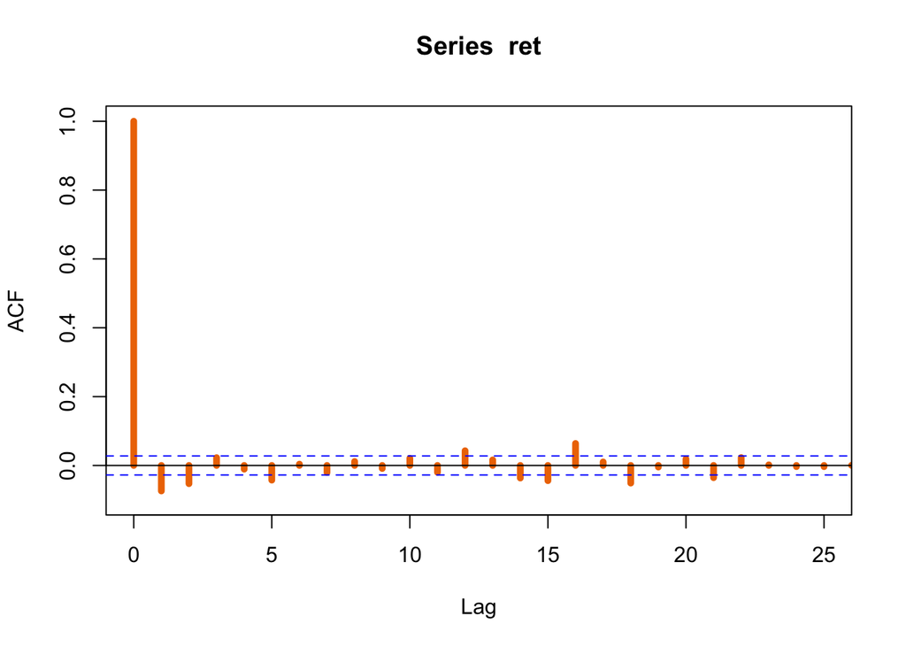

```r
ret.acf <- acf(ret , ylim=c(-0.1,1) , lwd=5 , xlim=c(0,25) , col='darkorange2')
```

```r
round(head(ret.acf$acf, 5), 3) #going into ret.acf function, tell it what to look for.
```

```
## , , 1
##
##        [,1]
## [1,]  1.000
## [2,] -0.074
## [3,] -0.053
## [4,]  0.023
## [5,] -0.011
```

```r
ret.acf
```

```
##
## Autocorrelations of series 'ret', by lag
##
##      0      1      2      3      4      5      6      7      8      9     10
##  1.000 -0.074 -0.053  0.023 -0.011 -0.043  0.004 -0.021  0.012 -0.009  0.021
##     11     12     13     14     15     16     17     18     19     20     21
## -0.020  0.043  0.016 -0.037 -0.044  0.064  0.010 -0.051 -0.005  0.019 -0.035
##     22     23     24     25     26     27     28     29     30     31     32
##  0.023  0.002 -0.003 -0.003  0.001  0.024 -0.007  0.013  0.011 -0.007  0.009
##     33     34     35     36     37
## -0.009 -0.065  0.014  0.019 -0.009
```

## 7.2 PACF

Partial auto-correlation function finds correlation of the residuals which can remain after removing the effects which are already explained by other lags.

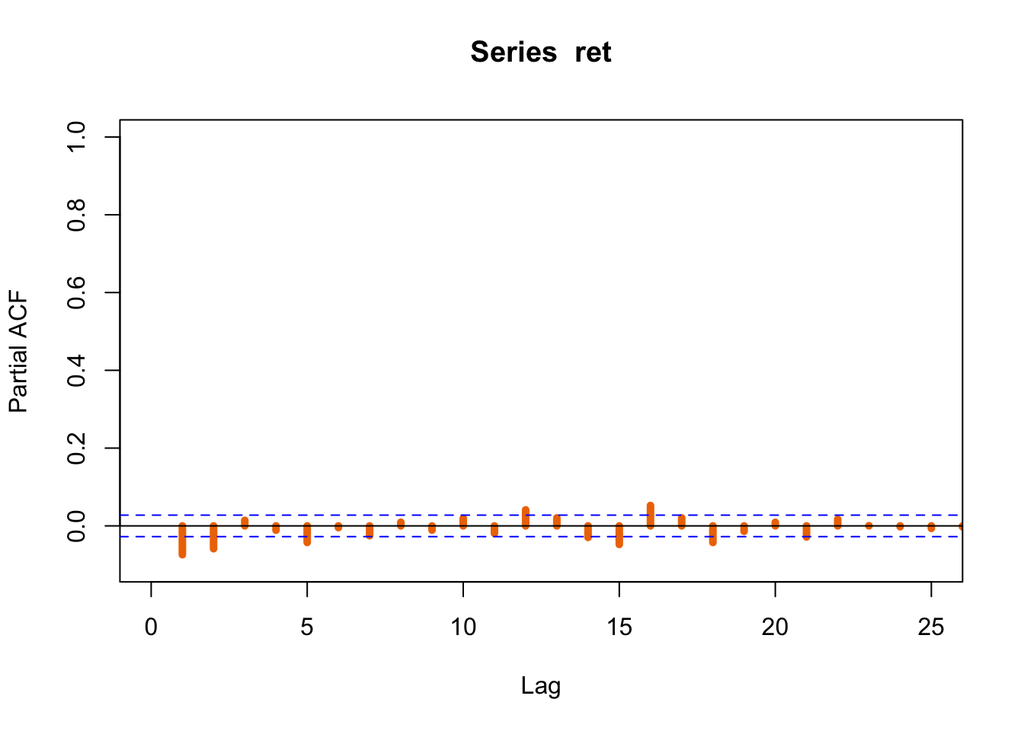

```r
#compared to ACF, here we partial out all past influences up to k (??)
ret.pacf <- pacf(ret, ylim=c(-0.1,1) , lwd=5 , xlim=c(0,25) , col='darkorange2')
```

```r
ret.pacf
```

```
##
## Partial autocorrelations of series 'ret', by lag
##
##      1      2      3      4      5      6      7      8      9     10     11
## -0.074 -0.059  0.014 -0.011 -0.043 -0.004 -0.025  0.009 -0.011  0.019 -0.019
##     12     13     14     15     16     17     18     19     20     21     22
##  0.041  0.021 -0.030 -0.048  0.052  0.021 -0.043 -0.014  0.009 -0.028  0.017
##     23     24     25     26     27     28     29     30     31     32     33
##  0.000 -0.002 -0.006 -0.002  0.031 -0.008  0.010  0.014  0.007  0.004 -0.012
##     34     35     36     37
## -0.061  0.005  0.012  0.000
```

## 7.3 Ljung-Box Test

A significant p-value in this test rejects the null hypothesis that the time series isn’t autocorrelated

```r
Box.test( ret , lag=22 , type="Ljung-Box" )
```

```
##
##  Box-Ljung test
##
## data:  ret
## X-squared = 133.75, df = 22, p-value < 2.2e-16
```

# 8 Finish Up with Virtual Environment renv

Save state of project library to `renv.lock`

```r
renv::snapshot()
```

```
## * The lockfile is already up to date.
```